# PS811 Portfolio

Monica Komer

### Research Interests

The overarching focus of my research is on the causes and consequences of women’s representation with a particular focus on the Middle East and North Africa. More specifically, I am interested in studying how (and which) women gain leadership positions in political parties and the effect of women’s presence on citizen’s attitudes and behaviors.

### Questions I hope to answer

Which women gain leadership positions in secular and religious parties? What determines which women run, where (i.e. district location) they run, and their position on party lists?

Do female politicians interact with constituents differently than their male colleagues? Is this conditional on party affiliation or quota type? Are citizens more loyal to regimes that enact gender quotas? Are women more interested in politics when represented by a woman instead of a male?

### Methods

Various regression models including hierarchical models, survey experiments, text analysis, and qualitative methods (primarily interviews and focus groups).

### Relevent data

- Arab Barometer ( [data](http://www.arabbarometer.org/survey-data/) )
- World Values Survey ( [data](http://www.worldvaluessurvey.org/WVSContents.jsp) )
- Afro Barometer ( data )
- Quota Adoption and Reform over Time (QAROT) dataset ( [data](https://www.openicpsr.org/openicpsr/project/100918/version/V1/view) )
- Tunisia Election Data (results by district available [here](http://tunisiaelectiondata.com/) )

### Is there a gender gap in attitudes towards female politicians? Do attitudes vary by country?

Using Arab Barometer data to evaluate attitudes towards female leaders:

```r
d <- read.csv(here("data/ABIV_English_subset.csv"))
```

I evaluate responses to the statement: “men are better at political leadership than women.” I recode this variable:

```r
#naming things and recoding leader variable (so higher values indicate more gender egalitarian views)
d$leader <- as.numeric(d$q6013)
d$leader[as.numeric(d$q6013) == 3] <- 2
d$leader[as.numeric(d$q6013) == 4] <- 3
d$leader[as.numeric(d$q6013) == 5] <- 1
d$leader[as.numeric(d$q6013) == 6] <- 4
d$leader[as.numeric(d$q6013) < 3] <- NA


d$female <- as.numeric(d$q1002)
d$female[as.numeric(d$q1002) == 2] <- 0
```

Mean response by gender and country with higher values indicating more gender egalitarian views (i.e., less supportive of the statement that “men are better at political leadership than women”):

```r
#Mean response by gender
d %>%
  group_by(female) %>% summarise(leader = mean(leader, na.rm=TRUE))
```

```
## # A tibble: 2 x 2
##   female leader
##    <dbl>  <dbl>
## 1     0.   1.95
## 2     1.   2.22
```

```r
#Mean response by country
d %>%
  group_by(country) %>% summarise(leader = mean(leader, na.rm=TRUE))
```

```
## # A tibble: 7 x 2
##   country   leader
##   <fct>      <dbl>
## 1 Algeria     1.83
## 2 Egypt       1.79
## 3 Jordan      1.91
## 4 Lebanon     2.33
## 5 Morocco     2.39
## 6 Palestine   2.02
## 7 Tunisia     2.32
```

Plotting responses by age and gender:

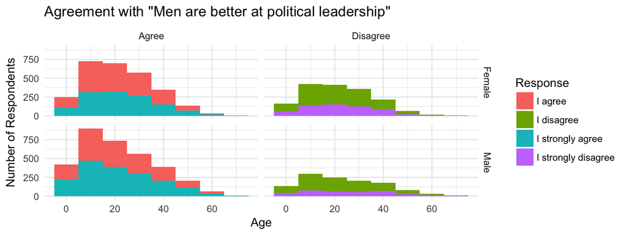

```r
d %>%
  mutate(age = as.numeric(q1001),
         gender = q1002) %>%
  mutate(agree = ifelse(str_detect(q6013,"agree"), "Agree", NA)) %>%
  mutate(agree = ifelse(str_detect(q6013, "disagree"), "Disagree", agree)) %>%
  filter(!is.na(agree) ) %>%
  ggplot() +
  aes(x = age, fill = q6013) +
  labs(x= "Age", y = "Number of Respondents", fill = "Response", title= "Agreement with ''Men are better at political leadership'' ") +
  geom_histogram(binwidth = 10) + facet_grid(gender ~ agree)
```

```r
d %>%
  group_by(country) %>%
  mutate(leader_m = mean(leader, na.rm= TRUE)) %>%
  distinct(country, leader_m) %>%
  ggplot() +
  aes(x = reorder(country, leader_m), y = leader_m) +
  labs(x= "Country", y="Mean Response", title= "Attitudes Towards Female Leaders") +
  geom_histogram(binwidth= 15, stat= "identity")
```

[output not shown]

We can also visualize the mean response by gender and country (with larger values indicating more gender egalitarian attitudes):

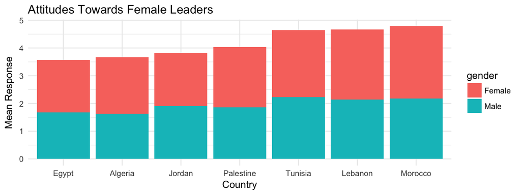

```r
d %>%
  mutate(gender = q1002) %>%
  group_by(country, gender) %>%
  mutate(leader_m = mean(leader, na.rm= TRUE)) %>%
  distinct(country, leader_m) %>%
  ggplot() +
  aes(x = reorder(country, leader_m), y = leader_m, fill = gender) +
  labs(x= "Country", y="Mean Response", title="Attitudes Towards Female Leaders") +
  geom_histogram(binwidth=8, stat= "identity")
```

An alternative, and somewhat easier, way to visualize the gender gap in attitudes towards female leaders:

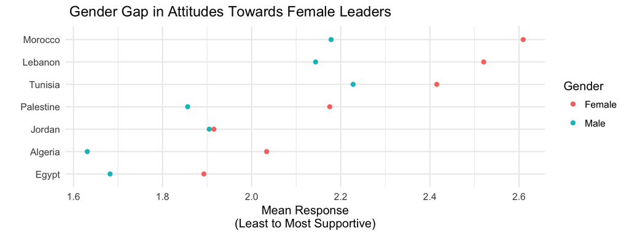

```r
d %>%
  mutate(gender = q1002) %>%
  group_by(country, gender) %>%
  mutate(leader_m = mean(leader, na.rm= TRUE)) %>%
  distinct(country, leader_m) %>%
  ggplot() +
  geom_point() +
  aes(y = reorder(country, leader_m), x = leader_m, color = gender) +
  labs(y=" " ,x="Mean Response\n(Least to Most Supportive)", title= " Gender Gap in Attitudes Towards Female Leaders", color = "Gender")
```

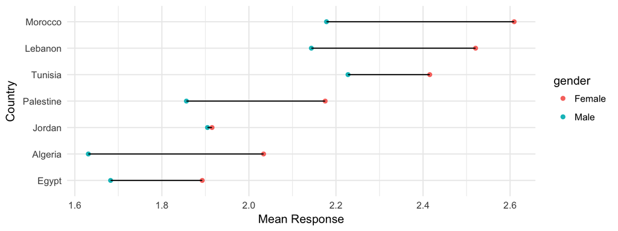

```r
d %>%
  mutate(gender = q1002) %>%
  group_by(country, gender) %>%
  mutate(leader_m = mean(leader, na.rm= TRUE)) %>%
  distinct(country, leader_m) %>%
  ggplot() +
  geom_point(aes(color=gender)) +
  aes(y = reorder(country, leader_m), x = leader_m) +
  labs(y= "Country", x="Mean Response") +
  geom_line()
```

### Effects of Women’s Representation on Public Opinion

Using Arab Barometer survey data and data from Tunisia’s 2014 parliamentary elections:

```r
abIV <- read.csv(here("data/ABIV_English_subset.csv"))
elect <- read.csv(here("Data/TUN2014PAR_Gov.csv"))
```

Merging and recoding the data:

```r
abIV <- read.csv(here("data/ABIV_English_subset.csv"))
elect <- read.csv(here("Data/TUN2014PAR_Gov.csv"))

abTun <- filter(abIV, country =="Tunisia")
abTun$governorate<- as.character(abTun$q1)

abtun<- full_join(abTun, elect, by= "governorate")

#creating variable to measure gender egalitarianism
abtun$leader <- as.numeric(abtun$q6013)

abtun$leader %<>%  # reorder so higher values mean more gender egal
  recode('5' = 1, #strongly agree
         '3' = 2,
         '2' = 3,
         '4' = 4,
         '6' = 5,
         .default = NaN)


#Binary
abtun$leaderdi <- abtun$leader
abtun$leaderdi %<>%
  recode('5' = 1,
         '4' = 1,
         '2' = 0,
         '1' = 0,
         .default = NaN)

#Gender Var
abtun$female <- as.numeric(abtun$q1002)

abtun$female %<>%
  recode('1' = 1,
         '2' = 0,
         .default = NaN)
```

Plotting average gender egalitarian attitudes (binary measure) by women’s representation across disricts:

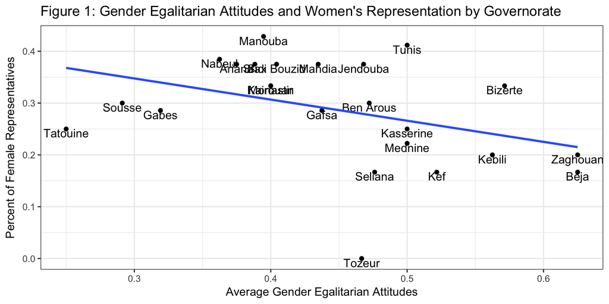

```r
##Plotting women's rep and avg gender egalitarian attitude by governorate
abtun %>%
  group_by(governorate) %>%
  mutate(meanleaderdi = mean(leaderdi, na.rm= TRUE)) %>%
  distinct(per_wom, meanleaderdi, governorate) %>%
  ggplot() +
  aes(x = meanleaderdi, y = per_wom) +
  geom_point() +
  geom_text(aes(label= governorate, vjust = 1)) +
  theme_bw() +
  geom_smooth(method=lm, se=FALSE) +
  labs(title= "Figure 1: Gender Egalitarian Attitudes and Women's Representation by Governorate",
       x= "Average Gender Egalitarian Attitudes",
       y= "Percent of Female Representatives")
```

$$logit(y)=B_0 + B_1 * Percent Women_j + B_2 * Head Women_j + B_3 * Female_{ij} + u_j$$

```r
test1 <- (glmer(leaderdi ~ per_wom + headwom_di + female + (1|governorate), weights = wt,
                data= abtun, family=binomial(link="logit")))

summary(test1)
```

```
## Generalized linear mixed model fit by maximum likelihood (Laplace
##   Approximation) [glmerMod]
##  Family: binomial  ( logit )
## Formula: leaderdi ~ per_wom + headwom_di + female + (1 | governorate)
##    Data: abtun
## Weights: wt
##
##      AIC      BIC   logLik deviance df.resid
##   1615.3   1640.7   -802.6   1605.3     1173
##
## Scaled residuals:
##     Min      1Q  Median      3Q     Max
## -1.2339 -0.8735 -0.7204  1.0590  1.4910
##
## Random effects:
##  Groups      Name        Variance Std.Dev.
##  governorate (Intercept) 0.02244  0.1498
## Number of obs: 1178, groups:  governorate, 24
##
## Fixed effects:
##             Estimate Std. Error z value Pr(>|z|)
## (Intercept)  0.18872    0.31564   0.598   0.5499
## per_wom     -1.83802    1.07949  -1.703   0.0886 .
## headwom_di   0.07658    0.18164   0.422   0.6733
## female       0.23798    0.11824   2.013   0.0441 *
## ---
## Signif. codes:  0 '***' 0.001 '**' 0.01 '*' 0.05 '.' 0.1 ' ' 1
##
## Correlation of Fixed Effects:
##            (Intr) per_wm hdwm_d
## per_wom    -0.943
## headwom_di  0.467 -0.636
## female     -0.181 -0.008  0.003
```

Plotting the Effect:

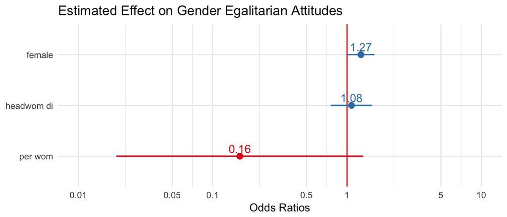

```r
plot_model(test1, show.values= TRUE, show.p = FALSE, vline.color = "red") +
  labs(title = "Estimated Effect on Gender Egalitarian Attitudes")
```

Predicted Probability of women’s representation on gender egalitarian attitudes with confidence bounds:

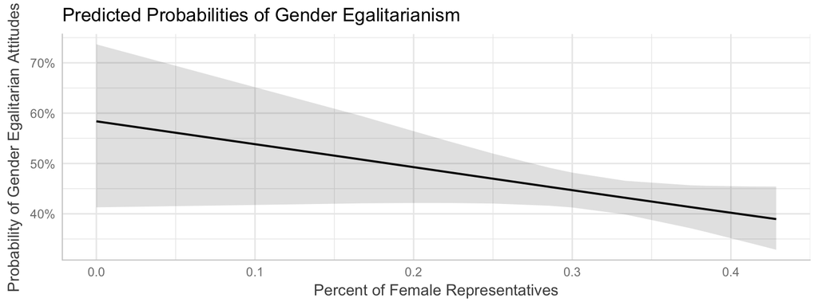

```r
plot(ggpredict(test1, terms = c("per_wom"))) +
labs(title= "Predicted Probabilities of Gender Egalitarianism",
     x= "Percent of Female Representatives",
     y= "Probability of Gender Egalitarian Attitudes")
```

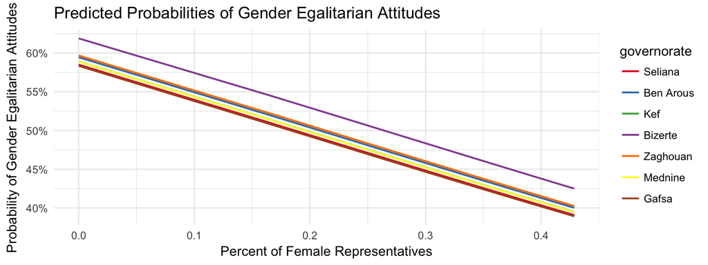

```r
#predicted prob for random set of 7 disricts
plot_model(test1,type="pred",
           terms=c("per_wom","governorate [sample = 7]"),pred.type="re") +
  labs(title= "Predicted Probabilities of Gender Egalitarian Attitudes",
       x = "Percent of Female Representatives",
       y= "Probability of Gender Egalitarian Attitudes")
```